# **1 | INTRODUCTION**

This is a survey to explore the linkage between mental illness and unemployment. The author of this survey mentioned that National Alliance on Mental Illness(NAMI) has condicted several surveys verifying the high unemployment rate among those with mental illness.

However, this is the only survey to date which targets causation. Today in this project we would like to reproduce the original findings using the original data join with new data that we collected.

**1.1 | STEPS**

The step of our project: - Make a survey to collection the information.

1. Collect Data
2. Import Library
3. Load Data
4. EDA
5. Label Encoding
6. Model
7. Comparison

# **2 | COLLECT DATA**

We collected data by the survey below.

- See more detail in [Kaggle Link - ATUL SINGH](https://www.kaggle.com/code/atulyaatul1999/mental-health-analysis-with-recall-score-1/notebook)
- Collect more data [The Survey](https://docs.google.com/forms/d/e/1FAIpQLSfBwspm9I3s5skzYVjWk1TZ-5c8yh1jlfJT4pYWizAfk-H6Tg/viewform)

# **3 | IMPORT LIBRARY**

**3.1 | Import Necessary Modules**

```python
import numpy as np # Mathematical Functions
import pandas as pd # Data processing
import seaborn as sns # Data Visualization
import matplotlib.pyplot as plt # Creating Static Visualizations
import os # Establish The Interaction
import seaborn as sns # Data Visualization
import matplotlib.pyplot as plt # Data Visualization
from sklearn.preprocessing import LabelEncoder # label encoding
from sklearn.preprocessing import StandardScaler
from sklearn.model_selection import train_test_split # splitting the data
from sklearn.linear_model import LogisticRegression # logistic regression function
from sklearn.metrics import confusion_matrix,precision_score,recall_score,accuracy_score #accuracy score
from sklearn.ensemble import RandomForestClassifier #random forest function
import warnings
os.getcwd()
```

```
'/Users/jeank4723/Desktop/RR/RR_project_2022'
```

**3.2 | Load Data**

```python
df_v=pd.read_excel('Cleaned Data.xlsx')

df_d=pd.read_excel('Mental Health Analysis (Odpowiedzi).xlsx')
```

```python
df_v.head()
```

|  | I am currently employed at least part-time | I identify as having a mental illness | Education | I have my own computer separate from a smart phone | I have been hospitalized before for my mental illness | How many days were you hospitalized for your mental illness | I am legally disabled | I have my regular access to the internet | I live with my parents | I have a gap in my resume | ... | Obsessive thinking | Mood swings | Panic attacks | Compulsive behavior | Tiredness | Age | Gender | Household Income | Region | Device Type |
| --- | --- | --- | --- | --- | --- | --- | --- | --- | --- | --- | --- | --- | --- | --- | --- | --- | --- | --- | --- | --- | --- |
| 0 | 0 | 0 | High School or GED | 0 | 0 | 0.0 | 0 | 1 | 0 | 1 | ... | 1.0 | 0.0 | 1.0 | 0.0 | 0.0 | 30-44 | Male | $25,000-$49,999 | Mountain | Android Phone / Tablet |
| 1 | 1 | 1 | Some Phd | 1 | 0 | 0.0 | 0 | 1 | 0 | 0 | ... | 0.0 | 0.0 | 1.0 | 0.0 | 1.0 | 18-29 | Male | $50,000-$74,999 | East South Central | MacOS Desktop / Laptop |
| 2 | 1 | 0 | Completed Undergraduate | 1 | 0 | 0.0 | 0 | 1 | 0 | 0 | ... | 0.0 | 0.0 | 0.0 | 0.0 | 0.0 | 30-44 | Male | $150,000-$174,999 | Pacific | MacOS Desktop / Laptop |
| 3 | 0 | 0 | Some Undergraduate | 1 | 0 | NaN | 0 | 1 | 1 | 1 | ... | 0.0 | 0.0 | 0.0 | 0.0 | 0.0 | 30-44 | Male | $25,000-$49,999 | New England | Windows Desktop / Laptop |
| 4 | 1 | 1 | Completed Undergraduate | 1 | 1 | 35.0 | 1 | 1 | 0 | 1 | ... | 1.0 | 1.0 | 1.0 | 1.0 | 1.0 | 30-44 | Male | $25,000-$49,999 | East North Central | iOS Phone / Tablet |

5 rows × 31 columns

```python
df_d.head()
```

|  | I am currently employed at least part-time | I identify as having a mental illness | Education | I have my own computer separate from a smart phone | I have been hospitalized before for my mental illness | How many days were you hospitalized for your mental illness (Put 0 if you never been hospitalized) | I am legally disabled | I have my regular access to the internet | I live with my parents | I have a gap in my resume | ... | Obsessive thinking | Mood swings | Panic attacks | Compulsive behavior | Tiredness | Age | Gender | Household Income (Put Number) | Region | Device Type |
| --- | --- | --- | --- | --- | --- | --- | --- | --- | --- | --- | --- | --- | --- | --- | --- | --- | --- | --- | --- | --- | --- |
| 0 | Yes | No | Some Masters | Yes | No | 0 | No | Yes | No | Yes | ... | No | No | No | No | Yes | 18-29 | Female | 16000 | Poland | iOS Phone / Tablet |
| 1 | Yes | No | Some Masters | Yes | No | 0 | No | Yes | No | Yes | ... | No | Yes | No | No | Yes | 18-29 | Female | 40000 | Poland | Windows Desktop / Laptop |
| 2 | Yes | No | Completed Underraduate | Yes | No | 0 | No | Yes | No | Yes | ... | Yes | Yes | No | Yes | Yes | 18-29 | Male | 20000 | Poland | MacOS Desktop / Laptop |
| 3 | Yes | Yes | Some Undergraduate | Yes | No | 0 | No | Yes | No | Yes | ... | Yes | Yes | No | Yes | Yes | 30-44 | Female | 40800 | Poland | Windows Desktop / Laptop |
| 4 | Yes | No | Some Masters | Yes | No | 0 | No | Yes | No | Yes | ... | Yes | No | No | No | No | 30-44 | Male | 36000 | Poland | iOS Phone / Tablet |

5 rows × 31 columns

```python
list(df_v.columns)
```

```
['I am currently employed at least part-time',
 'I identify as having a mental illness',
 'Education',
 'I have my own computer separate from a smart phone',
 'I have been hospitalized before for my mental illness',
 'How many days were you hospitalized for your mental illness',
 'I am legally disabled',
 'I have my regular access to the internet',
 'I live with my parents',
 'I have a gap in my resume',
 'Total length of any gaps in my resume in\xa0months.',
 'Annual income (including any social welfare programs) in USD',
 'I am unemployed',
 'I read outside of work and school',
 'Annual income from social welfare programs',
 'I receive food stamps',
 'I am on section 8 housing',
 'How many times were you hospitalized for your mental illness',
 'Lack of concentration',
 'Anxiety',
 'Depression',
 'Obsessive thinking',
 'Mood swings',
 'Panic attacks',
 'Compulsive behavior',
 'Tiredness',
 'Age',
 'Gender',
 'Household Income',
 'Region',
 'Device Type']
```

```python
# Rename All The Columns in df_d
df_d.columns = list(df_v.columns)
```

```python
df_d
```

|  | I am currently employed at least part-time | I identify as having a mental illness | Education | I have my own computer separate from a smart phone | I have been hospitalized before for my mental illness | How many days were you hospitalized for your mental illness | I am legally disabled | I have my regular access to the internet | I live with my parents | I have a gap in my resume | ... | Obsessive thinking | Mood swings | Panic attacks | Compulsive behavior | Tiredness | Age | Gender | Household Income | Region | Device Type |
| --- | --- | --- | --- | --- | --- | --- | --- | --- | --- | --- | --- | --- | --- | --- | --- | --- | --- | --- | --- | --- | --- |
| 0 | Yes | No | Some Masters | Yes | No | 0 | No | Yes | No | Yes | ... | No | No | No | No | Yes | 18-29 | Female | 16000 | Poland | iOS Phone / Tablet |
| 1 | Yes | No | Some Masters | Yes | No | 0 | No | Yes | No | Yes | ... | No | Yes | No | No | Yes | 18-29 | Female | 40000 | Poland | Windows Desktop / Laptop |
| 2 | Yes | No | Completed Underraduate | Yes | No | 0 | No | Yes | No | Yes | ... | Yes | Yes | No | Yes | Yes | 18-29 | Male | 20000 | Poland | MacOS Desktop / Laptop |
| 3 | Yes | Yes | Some Undergraduate | Yes | No | 0 | No | Yes | No | Yes | ... | Yes | Yes | No | Yes | Yes | 30-44 | Female | 40800 | Poland | Windows Desktop / Laptop |
| 4 | Yes | No | Some Masters | Yes | No | 0 | No | Yes | No | Yes | ... | Yes | No | No | No | No | 30-44 | Male | 36000 | Poland | iOS Phone / Tablet |
| 5 | Yes | No | Completed Masters | Yes | No | 0 | No | Yes | No | No | ... | Yes | Yes | Yes | Yes | Yes | 30-44 | Male | 200000 | Poland | Android Phone / Tablet |
| 6 | Yes | No | Completed Underraduate | Yes | No | 0 | No | Yes | No | No | ... | No | No | No | No | Yes | 30-44 | Female | 0 | Poland | MacOS Desktop / Laptop |
| 7 | Yes | No | Completed Masters | Yes | No | 0 | No | Yes | No | Yes | ... | No | No | No | No | Yes | 18-29 | Male | 300000 | Poland | Windows Desktop / Laptop |
| 8 | Yes | No | Some Masters | Yes | No | 0 | No | Yes | No | No | ... | No | No | No | No | No | 18-29 | Male | 100000 | Poland | Windows Desktop / Laptop |
| 9 | No | No | High School or GED | Yes | No | 0 | No | Yes | Yes | No | ... | No | Yes | Yes | No | No | 18-29 | Female | 60000 | Poland | iOS Phone / Tablet |
| 10 | Yes | No | Some Masters | Yes | No | 0 | No | Yes | No | No | ... | No | No | No | No | Yes | 18-29 | Male | 60000 | Poland | Android Phone / Tablet |
| 11 | Yes | No | Completed Underraduate | No | No | 0 | No | Yes | Yes | No | ... | Yes | Yes | No | No | No | 30-44 | Female | 600000 | Poland | Windows Desktop / Laptop |
| 12 | Yes | No | Completed Underraduate | Yes | No | 0 | No | Yes | No | Yes | ... | No | No | No | No | No | 30-44 | Female | 300000 | Poland | Android Phone / Tablet |
| 13 | Yes | No | Completed Masters | Yes | No | 0 | No | Yes | No | Yes | ... | No | No | No | No | Yes | 18-29 | Female | 53000 | Poland | iOS Phone / Tablet |
| 14 | No | Yes | Completed Underraduate | Yes | No | 0 | No | Yes | No | Yes | ... | Yes | No | No | No | No | 18-29 | Male | 60000 | Poland | Other |
| 15 | Yes | No | Some Masters | Yes | No | 0 | No | Yes | No | No | ... | Yes | Yes | No | No | Yes | 18-29 | Female | 500000 | Poland | Windows Desktop / Laptop |
| 16 | Yes | No | Completed Masters | Yes | No | 0 | No | Yes | No | Yes | ... | No | Yes | No | No | No | 30-44 | Female | 48000 | Poland | MacOS Desktop / Laptop |
| 17 | Yes | No | Completed Masters | Yes | No | 0 | No | Yes | No | No | ... | No | Yes | No | No | No | 30-44 | Male | 0 | Poland | Windows Desktop / Laptop |
| 18 | Yes | No | Some Masters | Yes | No | 0 | No | Yes | No | No | ... | No | No | No | No | No | 18-29 | Male | 100000 | Poland | Android Phone / Tablet |
| 19 | Yes | Yes | Completed Masters | Yes | No | 0 | No | Yes | Yes | No | ... | Yes | No | No | No | No | 30-44 | Male | 146705 | Poland | Windows Desktop / Laptop |
| 20 | No | No | Completed Underraduate | Yes | No | 0 | No | Yes | No | Yes | ... | No | No | No | No | Yes | 30-44 | Female | 20000 | Poland | Android Phone / Tablet |
| 21 | Yes | No | Completed Underraduate | Yes | No | 0 | No | Yes | No | No | ... | No | Yes | No | No | Yes | 18-29 | Female | 0 | Poland | MacOS Desktop / Laptop |
| 22 | Yes | No | Some Masters | Yes | No | 0 | No | Yes | No | Yes | ... | No | No | No | No | Yes | 18-29 | Female | 16000 | Poland | iOS Phone / Tablet |
| 23 | Yes | No | Some Masters | Yes | No | 0 | No | Yes | No | Yes | ... | No | Yes | No | No | Yes | 18-29 | Female | 40000 | Poland | Windows Desktop / Laptop |
| 24 | Yes | No | Completed Underraduate | Yes | No | 0 | No | Yes | No | Yes | ... | Yes | Yes | No | Yes | Yes | 18-29 | Male | 20000 | Poland | MacOS Desktop / Laptop |
| 25 | Yes | Yes | Some Undergraduate | Yes | No | 0 | No | Yes | No | Yes | ... | Yes | Yes | No | Yes | Yes | 30-44 | Female | 40800 | Poland | Windows Desktop / Laptop |
| 26 | Yes | No | Some Masters | Yes | No | 0 | No | Yes | No | Yes | ... | Yes | No | No | No | No | 30-44 | Male | 36000 | Poland | iOS Phone / Tablet |
| 27 | Yes | No | Completed Masters | Yes | No | 0 | No | Yes | No | No | ... | Yes | Yes | Yes | Yes | Yes | 30-44 | Male | 200000 | Poland | Android Phone / Tablet |
| 28 | Yes | No | Completed Underraduate | Yes | No | 0 | No | Yes | No | No | ... | No | No | No | No | Yes | 30-44 | Female | 0 | Poland | MacOS Desktop / Laptop |
| 29 | Yes | No | Completed Masters | Yes | No | 0 | No | Yes | No | Yes | ... | No | No | No | No | Yes | 18-29 | Male | 300000 | Poland | Windows Desktop / Laptop |
| 30 | Yes | No | Some Masters | Yes | No | 0 | No | Yes | No | No | ... | No | No | No | No | No | 18-29 | Male | 100000 | Poland | Windows Desktop / Laptop |
| 31 | No | No | High School or GED | Yes | No | 0 | No | Yes | Yes | No | ... | No | Yes | Yes | No | No | 18-29 | Female | 60000 | Poland | iOS Phone / Tablet |
| 32 | Yes | No | Some Masters | Yes | No | 0 | No | Yes | No | No | ... | No | No | No | No | Yes | 18-29 | Male | 60000 | Poland | Android Phone / Tablet |
| 33 | Yes | No | Completed Underraduate | No | No | 0 | No | Yes | Yes | No | ... | Yes | Yes | No | No | No | 30-44 | Female | 600000 | Poland | Windows Desktop / Laptop |
| 34 | Yes | No | Completed Underraduate | Yes | No | 0 | No | Yes | No | Yes | ... | No | No | No | No | No | 30-44 | Female | 300000 | Poland | Android Phone / Tablet |
| 35 | Yes | No | Completed Masters | Yes | No | 0 | No | Yes | No | Yes | ... | No | No | No | No | Yes | 18-29 | Female | 53000 | Poland | iOS Phone / Tablet |
| 36 | No | Yes | Completed Underraduate | Yes | No | 0 | No | Yes | No | Yes | ... | Yes | No | No | No | No | 18-29 | Male | 60000 | Poland | Other |
| 37 | Yes | No | Some Masters | Yes | No | 0 | No | Yes | No | No | ... | Yes | Yes | No | No | Yes | 18-29 | Female | 500000 | Poland | Windows Desktop / Laptop |
| 38 | Yes | No | Completed Masters | Yes | No | 0 | No | Yes | No | Yes | ... | No | Yes | No | No | No | 30-44 | Female | 48000 | Poland | MacOS Desktop / Laptop |
| 39 | Yes | No | Completed Masters | Yes | No | 0 | No | Yes | No | No | ... | No | Yes | No | No | No | 30-44 | Male | 0 | Poland | Windows Desktop / Laptop |

40 rows × 31 columns

**3.2 | Clean Data**

```python
# Changed all the YES/NO into 1/0
df_d_new = df_d.replace({'Yes': 1,'No': 0})

# Changed the currency of the Income (1 U.S. dollar = 4.47753843 Polish zloty)
df_d_new['Household Income'] = df_d_new['Household Income']/4.47753843
df_d_new['Annual income (including any social welfare programs) in USD'] = df_d_new['Annual income (including any social welfare programs) in USD']/4.47753843
df_d_new['Annual income from social welfare programs'] = df_d_new['Annual income from social welfare programs']/4.47753843
```

```python
# Check the interval in column 'Household Income'
df_v['Household Income'].nunique()
# $0-$9,999
# $10,000-$24,999
# $25,000-$49,999
# $50,000-$74,999
# $75,000-$99,999
# $100,000-$124,999
# $125,000-$149,999
# $150,000-$174,999
# $175,000-$199,999
# $200,000+
# Prefer not to answer
```

```
11
```

```python
# Change the integer into interval string same as Clean Data
All_Conditions = [
    (df_d_new['Household Income'] >= 200000),
    (df_d_new['Household Income'] >= 175000) & (df_d_new['Household Income'] <= 199999),
    (df_d_new['Household Income'] >= 150000) & (df_d_new['Household Income'] <= 174999),
    (df_d_new['Household Income'] >= 125000) & (df_d_new['Household Income'] <= 149999),
    (df_d_new['Household Income'] >= 100000) & (df_d_new['Household Income'] <= 124999),
    (df_d_new['Household Income'] >= 75000) & (df_d_new['Household Income'] <= 99999),
    (df_d_new['Household Income'] >= 50000) & (df_d_new['Household Income'] <= 74999),
    (df_d_new['Household Income'] >= 25000) & (df_d_new['Household Income'] <= 49999),
    (df_d_new['Household Income'] >= 10000) & (df_d_new['Household Income'] <= 24999),
    (df_d_new['Household Income'] >= 0) & (df_d_new['Household Income'] <= 9999)
]
All_Categories = ['$200,000+','$175,000-$199,999', '$150,000-$174,999',
                  '$125,000-$149,999', '$100,000-$124,999',
                  '$75,000-$99,999' ,'$50,000-$74,999',
                  '$25,000-$49,999', '$10,000-$24,999',
                  '$0-$9,999'
]
df_d_new['Household Income'] = np.select(All_Conditions, All_Categories)
```

```python
df_d_new.dtypes
df_d_new.head()
```

|  | I am currently employed at least part-time | I identify as having a mental illness | Education | I have my own computer separate from a smart phone | I have been hospitalized before for my mental illness | How many days were you hospitalized for your mental illness | I am legally disabled | I have my regular access to the internet | I live with my parents | I have a gap in my resume | ... | Obsessive thinking | Mood swings | Panic attacks | Compulsive behavior | Tiredness | Age | Gender | Household Income | Region | Device Type |
| --- | --- | --- | --- | --- | --- | --- | --- | --- | --- | --- | --- | --- | --- | --- | --- | --- | --- | --- | --- | --- | --- |
| 0 | 1 | 0 | Some Masters | 1 | 0 | 0 | 0 | 1 | 0 | 1 | ... | 0 | 0 | 0 | 0 | 1 | 18-29 | Female | $0-$9,999 | Poland | iOS Phone / Tablet |
| 1 | 1 | 0 | Some Masters | 1 | 0 | 0 | 0 | 1 | 0 | 1 | ... | 0 | 1 | 0 | 0 | 1 | 18-29 | Female | $0-$9,999 | Poland | Windows Desktop / Laptop |
| 2 | 1 | 0 | Completed Underraduate | 1 | 0 | 0 | 0 | 1 | 0 | 1 | ... | 1 | 1 | 0 | 1 | 1 | 18-29 | Male | $0-$9,999 | Poland | MacOS Desktop / Laptop |
| 3 | 1 | 1 | Some Undergraduate | 1 | 0 | 0 | 0 | 1 | 0 | 1 | ... | 1 | 1 | 0 | 1 | 1 | 30-44 | Female | $0-$9,999 | Poland | Windows Desktop / Laptop |
| 4 | 1 | 0 | Some Masters | 1 | 0 | 0 | 0 | 1 | 0 | 1 | ... | 1 | 0 | 0 | 0 | 0 | 30-44 | Male | $0-$9,999 | Poland | iOS Phone / Tablet |

5 rows × 31 columns

**3.3 | Merge Data**

```python
df = df_v.append(df_d_new, ignore_index = True)
```

**3.4 | Analysis Data**

```python
df.tail()
```

|  | I am currently employed at least part-time | I identify as having a mental illness | Education | I have my own computer separate from a smart phone | I have been hospitalized before for my mental illness | How many days were you hospitalized for your mental illness | I am legally disabled | I have my regular access to the internet | I live with my parents | I have a gap in my resume | ... | Obsessive thinking | Mood swings | Panic attacks | Compulsive behavior | Tiredness | Age | Gender | Household Income | Region | Device Type |
| --- | --- | --- | --- | --- | --- | --- | --- | --- | --- | --- | --- | --- | --- | --- | --- | --- | --- | --- | --- | --- | --- |
| 369 | 1 | 0 | Completed Masters | 1 | 0 | 0.0 | 0 | 1 | 0 | 1 | ... | 0.0 | 0.0 | 0.0 | 0.0 | 1.0 | 18-29 | Female | $10,000-$24,999 | Poland | iOS Phone / Tablet |
| 370 | 0 | 1 | Completed Underraduate | 1 | 0 | 0.0 | 0 | 1 | 0 | 1 | ... | 1.0 | 0.0 | 0.0 | 0.0 | 0.0 | 18-29 | Male | $10,000-$24,999 | Poland | Other |
| 371 | 1 | 0 | Some Masters | 1 | 0 | 0.0 | 0 | 1 | 0 | 0 | ... | 1.0 | 1.0 | 0.0 | 0.0 | 1.0 | 18-29 | Female | $100,000-$124,999 | Poland | Windows Desktop / Laptop |
| 372 | 1 | 0 | Completed Masters | 1 | 0 | 0.0 | 0 | 1 | 0 | 1 | ... | 0.0 | 1.0 | 0.0 | 0.0 | 0.0 | 30-44 | Female | $10,000-$24,999 | Poland | MacOS Desktop / Laptop |
| 373 | 1 | 0 | Completed Masters | 1 | 0 | 0.0 | 0 | 1 | 0 | 0 | ... | 0.0 | 1.0 | 0.0 | 0.0 | 0.0 | 30-44 | Male | $0-$9,999 | Poland | Windows Desktop / Laptop |

5 rows × 31 columns

```python
# Missing Data
df.isnull().sum()
```

```
I am currently employed at least part-time                       0
I identify as having a mental illness                            0
Education                                                        0
I have my own computer separate from a smart phone               0
I have been hospitalized before for my mental illness            0
How many days were you hospitalized for your mental illness     37
I am legally disabled                                            0
I have my regular access to the internet                         0
I live with my parents                                           0
I have a gap in my resume                                        0
Total length of any gaps in my resume in months.                 0
Annual income (including any social welfare programs) in USD     0
I am unemployed                                                  0
I read outside of work and school                                0
Annual income from social welfare programs                       0
I receive food stamps                                            0
I am on section 8 housing                                        0
How many times were you hospitalized for your mental illness     0
Lack of concentration                                            1
Anxiety                                                          0
Depression                                                       0
Obsessive thinking                                               1
Mood swings                                                      1
Panic attacks                                                    1
Compulsive behavior                                              1
Tiredness                                                        1
Age                                                              0
Gender                                                           0
Household Income                                                 0
Region                                                           2
Device Type                                                      0
dtype: int64
```

```python
# Data Shape
df.shape
```

```
(374, 31)
```

# **4 | EDA**

**4.1 | Correlation**

```python
cor=df.corr()
cor
```

|  | I am currently employed at least part-time | I identify as having a mental illness | I have my own computer separate from a smart phone | I have been hospitalized before for my mental illness | How many days were you hospitalized for your mental illness | I am legally disabled | I have my regular access to the internet | I live with my parents | I have a gap in my resume | Total length of any gaps in my resume in months. | ... | I am on section 8 housing | How many times were you hospitalized for your mental illness | Lack of concentration | Anxiety | Depression | Obsessive thinking | Mood swings | Panic attacks | Compulsive behavior | Tiredness |
| --- | --- | --- | --- | --- | --- | --- | --- | --- | --- | --- | --- | --- | --- | --- | --- | --- | --- | --- | --- | --- | --- |
| I am currently employed at least part-time | 1.000000 | -0.091179 | 0.123634 | -0.165579 | -0.139525 | -0.311144 | 0.145966 | -0.174214 | -0.106570 | -0.244301 | ... | -0.125080 | -0.047602 | 0.017034 | -0.121386 | -0.105646 | -0.063148 | -0.046892 | -0.185709 | -0.009841 | 0.007888 |
| I identify as having a mental illness | -0.091179 | 1.000000 | -0.118818 | 0.428748 | 0.286196 | 0.236194 | -0.082284 | 0.130432 | 0.222680 | 0.223316 | ... | 0.019260 | 0.125934 | 0.316190 | 0.537944 | 0.700663 | 0.395347 | 0.323996 | 0.405600 | 0.376773 | 0.226077 |
| I have my own computer separate from a smart phone | 0.123634 | -0.118818 | 1.000000 | -0.128599 | -0.151631 | -0.120477 | 0.216067 | -0.159251 | -0.127856 | -0.158293 | ... | -0.010806 | -0.019549 | -0.002090 | -0.198536 | -0.094531 | -0.121876 | -0.144976 | -0.089222 | -0.053338 | 0.024651 |
| I have been hospitalized before for my mental illness | -0.165579 | 0.428748 | -0.128599 | 1.000000 | 0.544619 | 0.322681 | -0.069545 | 0.069264 | 0.184495 | 0.182636 | ... | 0.117397 | 0.362383 | 0.118747 | 0.221625 | 0.326337 | 0.293386 | 0.176345 | 0.310756 | 0.236859 | 0.123335 |
| How many days were you hospitalized for your mental illness | -0.139525 | 0.286196 | -0.151631 | 0.544619 | 1.000000 | 0.253178 | -0.049339 | 0.135074 | 0.145272 | 0.114074 | ... | 0.052787 | 0.663317 | -0.039908 | 0.160619 | 0.220211 | 0.165466 | 0.091929 | 0.261549 | 0.158692 | -0.012657 |
| I am legally disabled | -0.311144 | 0.236194 | -0.120477 | 0.322681 | 0.253178 | 1.000000 | 0.003147 | 0.128209 | 0.103651 | 0.197268 | ... | 0.096156 | 0.078443 | 0.130974 | 0.093073 | 0.232657 | 0.135953 | 0.109348 | 0.149515 | 0.131230 | 0.072102 |
| I have my regular access to the internet | 0.145966 | -0.082284 | 0.216067 | -0.069545 | -0.049339 | 0.003147 | 1.000000 | -0.031351 | -0.023612 | -0.095170 | ... | 0.025145 | -0.039973 | 0.006154 | -0.039632 | 0.000561 | -0.007019 | -0.091472 | 0.030683 | 0.006565 | 0.062340 |
| I live with my parents | -0.174214 | 0.130432 | -0.159251 | 0.069264 | 0.135074 | 0.128209 | -0.031351 | 1.000000 | 0.102998 | 0.027774 | ... | 0.013366 | 0.108466 | 0.076351 | 0.195872 | 0.125800 | 0.155143 | 0.225858 | 0.146531 | 0.147143 | -0.049485 |
| I have a gap in my resume | -0.106570 | 0.222680 | -0.127856 | 0.184495 | 0.145272 | 0.103651 | -0.023612 | 0.102998 | 1.000000 | 0.611115 | ... | 0.003188 | 0.050057 | 0.195242 | 0.173911 | 0.236121 | 0.237656 | 0.154327 | 0.212362 | 0.233100 | 0.131793 |
| Total length of any gaps in my resume in months. | -0.244301 | 0.223316 | -0.158293 | 0.182636 | 0.114074 | 0.197268 | -0.095170 | 0.027774 | 0.611115 | 1.000000 | ... | 0.140908 | 0.032450 | 0.122483 | 0.187440 | 0.173635 | 0.112104 | 0.100067 | 0.229903 | 0.228734 | 0.068934 |
| Annual income (including any social welfare programs) in USD | 0.140611 | -0.063787 | 0.093697 | -0.072176 | -0.060628 | -0.082802 | 0.048499 | -0.033975 | 0.099611 | -0.032065 | ... | -0.036913 | -0.036580 | 0.178943 | 0.049230 | -0.010163 | 0.169504 | 0.117724 | -0.008038 | 0.062829 | 0.156120 |
| I am unemployed | -0.751751 | 0.157398 | -0.202131 | 0.190433 | 0.145430 | 0.332084 | -0.110466 | 0.176177 | 0.199022 | 0.277343 | ... | 0.106870 | 0.066074 | 0.029933 | 0.169648 | 0.178508 | 0.108783 | 0.073954 | 0.237106 | 0.011925 | 0.007519 |
| I read outside of work and school | -0.009654 | 0.051970 | 0.021164 | 0.049072 | -0.016812 | 0.043274 | 0.014539 | -0.126309 | -0.080948 | -0.020890 | ... | 0.055500 | -0.013633 | 0.067354 | 0.006759 | 0.072501 | -0.001153 | -0.022665 | 0.075124 | 0.076429 | 0.033129 |
| Annual income from social welfare programs | 0.048964 | -0.040061 | 0.027183 | -0.018639 | -0.016267 | -0.021918 | 0.013100 | -0.026294 | -0.044283 | -0.030315 | ... | -0.010374 | -0.009269 | -0.033800 | -0.048500 | -0.043185 | -0.030486 | 0.178049 | -0.030376 | -0.022569 | -0.048683 |
| I receive food stamps | -0.233507 | 0.081349 | -0.226143 | 0.199746 | 0.028845 | 0.242741 | -0.147931 | 0.091036 | 0.176571 | 0.229555 | ... | 0.300876 | 0.097132 | 0.120009 | 0.074797 | 0.090918 | 0.083435 | 0.083435 | 0.126267 | 0.192618 | 0.043766 |
| I am on section 8 housing | -0.125080 | 0.019260 | -0.010806 | 0.117397 | 0.052787 | 0.096156 | 0.025145 | 0.013366 | 0.003188 | 0.140908 | ... | 1.000000 | 0.173795 | 0.038220 | 0.076056 | -0.034538 | -0.003827 | 0.051081 | 0.000303 | 0.158756 | -0.012193 |
| How many times were you hospitalized for your mental illness | -0.047602 | 0.125934 | -0.019549 | 0.362383 | 0.663317 | 0.078443 | -0.039973 | 0.108466 | 0.050057 | 0.032450 | ... | 0.173795 | 1.000000 | 0.035782 | 0.083389 | 0.142887 | 0.197066 | 0.161152 | 0.258380 | 0.261769 | -0.014519 |
| Lack of concentration | 0.017034 | 0.316190 | -0.002090 | 0.118747 | -0.039908 | 0.130974 | 0.006154 | 0.076351 | 0.195242 | 0.122483 | ... | 0.038220 | 0.035782 | 1.000000 | 0.330905 | 0.408341 | 0.383572 | 0.325342 | 0.289643 | 0.448193 | 0.343668 |
| Anxiety | -0.121386 | 0.537944 | -0.198536 | 0.221625 | 0.160619 | 0.093073 | -0.039632 | 0.195872 | 0.173911 | 0.187440 | ... | 0.076056 | 0.083389 | 0.330905 | 1.000000 | 0.574882 | 0.499762 | 0.435527 | 0.502694 | 0.416549 | 0.230707 |
| Depression | -0.105646 | 0.700663 | -0.094531 | 0.326337 | 0.220211 | 0.232657 | 0.000561 | 0.125800 | 0.236121 | 0.173635 | ... | -0.034538 | 0.142887 | 0.408341 | 0.574882 | 1.000000 | 0.444149 | 0.358034 | 0.457669 | 0.388344 | 0.285075 |
| Obsessive thinking | -0.063148 | 0.395347 | -0.121876 | 0.293386 | 0.165466 | 0.135953 | -0.007019 | 0.155143 | 0.237656 | 0.112104 | ... | -0.003827 | 0.197066 | 0.383572 | 0.499762 | 0.444149 | 1.000000 | 0.461581 | 0.403362 | 0.629910 | 0.275661 |
| Mood swings | -0.046892 | 0.323996 | -0.144976 | 0.176345 | 0.091929 | 0.109348 | -0.091472 | 0.225858 | 0.154327 | 0.100067 | ... | 0.051081 | 0.161152 | 0.325342 | 0.435527 | 0.358034 | 0.461581 | 1.000000 | 0.360680 | 0.451041 | 0.275661 |
| Panic attacks | -0.185709 | 0.405600 | -0.089222 | 0.310756 | 0.261549 | 0.149515 | 0.030683 | 0.146531 | 0.212362 | 0.229903 | ... | 0.000303 | 0.258380 | 0.289643 | 0.502694 | 0.457669 | 0.403362 | 0.360680 | 1.000000 | 0.422037 | 0.223658 |
| Compulsive behavior | -0.009841 | 0.376773 | -0.053338 | 0.236859 | 0.158692 | 0.131230 | 0.006565 | 0.147143 | 0.233100 | 0.228734 | ... | 0.158756 | 0.261769 | 0.448193 | 0.416549 | 0.388344 | 0.629910 | 0.451041 | 0.422037 | 1.000000 | 0.285188 |
| Tiredness | 0.007888 | 0.226077 | 0.024651 | 0.123335 | -0.012657 | 0.072102 | 0.062340 | -0.049485 | 0.131793 | 0.068934 | ... | -0.012193 | -0.014519 | 0.343668 | 0.230707 | 0.285075 | 0.275661 | 0.275661 | 0.223658 | 0.285188 | 1.000000 |

25 rows × 25 columns

**4.2 | Heat Map**

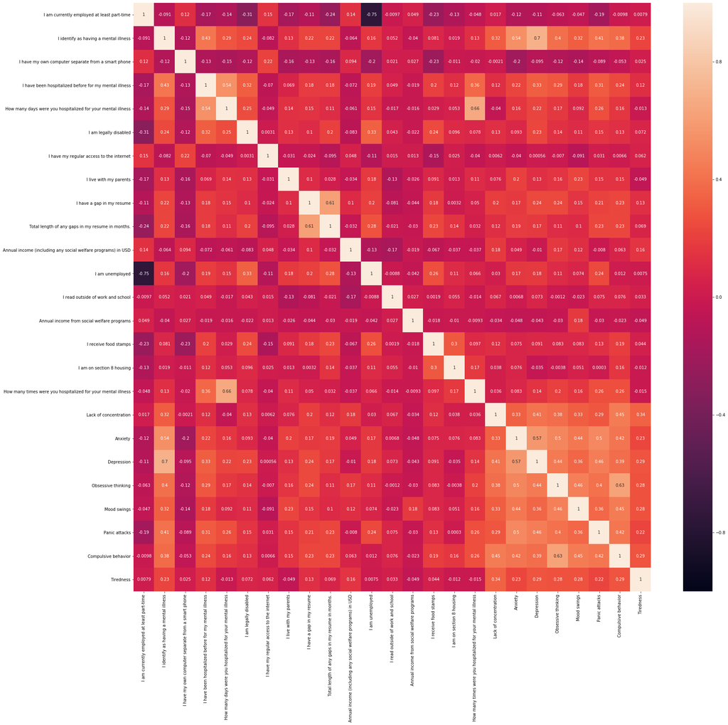

```python
fig = plt.figure(figsize=(22,20))

fig.add_axes([0,0,1,1])
ax = fig.get_axes()[0]
sns.heatmap(cor, ax=ax, vmin=-1, vmax=1, annot=True)
```

```python
# Columns of correlation with "I identify as having a mental illness"
cor.iloc[1]
```

```
I am currently employed at least part-time                     -0.091179
I identify as having a mental illness                           1.000000
I have my own computer separate from a smart phone             -0.118818
I have been hospitalized before for my mental illness           0.428748
How many days were you hospitalized for your mental illness     0.286196
I am legally disabled                                           0.236194
I have my regular access to the internet                       -0.082284
I live with my parents                                          0.130432
I have a gap in my resume                                       0.222680
Total length of any gaps in my resume in months.                0.223316
Annual income (including any social welfare programs) in USD   -0.063787
I am unemployed                                                 0.157398
I read outside of work and school                               0.051970
Annual income from social welfare programs                     -0.040061
I receive food stamps                                           0.081349
I am on section 8 housing                                       0.019260
How many times were you hospitalized for your mental illness    0.125934
Lack of concentration                                           0.316190
Anxiety                                                         0.537944
Depression                                                      0.700663
Obsessive thinking                                              0.395347
Mood swings                                                     0.323996
Panic attacks                                                   0.405600
Compulsive behavior                                             0.376773
Tiredness                                                       0.226077
Name: I identify as having a mental illness, dtype: float64
```

```python
# We will remove insignificant columns
columns_to_drop=['Region','I have my regular access to the internet','I am currently employed at least part-time','I am on section 8 housing','I receive food stamps','Annual income from social welfare programs','I have a gap in my resume','Total length of any gaps in my resume in\xa0months.','Household Income','Device Type']
```

```python
df.drop(columns=columns_to_drop,inplace=True)
```

```python
df.shape
```

```
(374, 21)
```

```python
df['Annual income (including any social welfare programs) in Rupee']=df['Annual income (including any social welfare programs) in USD']*70
```

```python
df.drop('Annual income (including any social welfare programs) in USD',axis=1,inplace=True)
```

```python
df.head(20)
```

|  | I identify as having a mental illness | Education | I have my own computer separate from a smart phone | I have been hospitalized before for my mental illness | How many days were you hospitalized for your mental illness | I am legally disabled | I live with my parents | I am unemployed | I read outside of work and school | How many times were you hospitalized for your mental illness | ... | Anxiety | Depression | Obsessive thinking | Mood swings | Panic attacks | Compulsive behavior | Tiredness | Age | Gender | Annual income (including any social welfare programs) in Rupee |
| --- | --- | --- | --- | --- | --- | --- | --- | --- | --- | --- | --- | --- | --- | --- | --- | --- | --- | --- | --- | --- | --- |
| 0 | 0 | High School or GED | 0 | 0 | 0.0 | 0 | 0 | 1 | 1 | 0 | ... | 1 | 1 | 1.0 | 0.0 | 1.0 | 0.0 | 0.0 | 30-44 | Male | 2450.0 |
| 1 | 1 | Some Phd | 1 | 0 | 0.0 | 0 | 0 | 0 | 1 | 0 | ... | 1 | 1 | 0.0 | 0.0 | 1.0 | 0.0 | 1.0 | 18-29 | Male | 1540.0 |
| 2 | 0 | Completed Undergraduate | 1 | 0 | 0.0 | 0 | 0 | 0 | 1 | 0 | ... | 0 | 0 | 0.0 | 0.0 | 0.0 | 0.0 | 0.0 | 30-44 | Male | 7000.0 |
| 3 | 0 | Some Undergraduate | 1 | 0 | NaN | 0 | 1 | 1 | 1 | 0 | ... | 0 | 0 | 0.0 | 0.0 | 0.0 | 0.0 | 0.0 | 30-44 | Male | 0.0 |
| 4 | 1 | Completed Undergraduate | 1 | 1 | 35.0 | 1 | 0 | 0 | 1 | 4 | ... | 1 | 1 | 1.0 | 1.0 | 1.0 | 1.0 | 1.0 | 30-44 | Male | 2240.0 |
| 5 | 0 | High School or GED | 1 | 0 | 0.0 | 0 | 1 | 0 | 1 | 0 | ... | 0 | 0 | 0.0 | 0.0 | 0.0 | 0.0 | 0.0 | 30-44 | Male | 0.0 |
| 6 | 0 | Some Undergraduate | 1 | 0 | 0.0 | 0 | 0 | 0 | 1 | 0 | ... | 0 | 0 | 0.0 | 0.0 | 0.0 | 0.0 | 0.0 | 18-29 | Male | 70.0 |
| 7 | 1 | Some Undergraduate | 1 | 0 | 0.0 | 0 | 1 | 0 | 1 | 0 | ... | 1 | 1 | 0.0 | 0.0 | 1.0 | 1.0 | 1.0 | 18-29 | Male | 770.0 |
| 8 | 0 | Completed Undergraduate | 1 | 0 | 0.0 | 0 | 0 | 0 | 1 | 0 | ... | 1 | 1 | 0.0 | 0.0 | 0.0 | 0.0 | 1.0 | 30-44 | Male | 5110.0 |
| 9 | 1 | Some Masters | 1 | 0 | 0.0 | 0 | 0 | 0 | 1 | 0 | ... | 1 | 1 | 0.0 | 0.0 | 0.0 | 0.0 | 1.0 | 30-44 | Male | 840.0 |
| 10 | 0 | Completed Undergraduate | 1 | 0 | NaN | 0 | 0 | 1 | 1 | 0 | ... | 0 | 0 | 0.0 | 0.0 | 0.0 | 0.0 | 0.0 | 30-44 | Male | 0.0 |
| 11 | 1 | Completed Undergraduate | 1 | 0 | 0.0 | 0 | 0 | 0 | 1 | 0 | ... | 1 | 0 | 1.0 | 0.0 | 0.0 | 1.0 | 0.0 | 18-29 | Male | 0.0 |
| 12 | 1 | Completed Undergraduate | 1 | 0 | 0.0 | 0 | 0 | 0 | 1 | 0 | ... | 1 | 1 | 0.0 | 0.0 | 0.0 | 0.0 | 0.0 | 30-44 | Male | 3500.0 |
| 13 | 0 | Completed Masters | 1 | 0 | 0.0 | 0 | 0 | 0 | 1 | 0 | ... | 0 | 0 | 0.0 | 0.0 | 0.0 | 0.0 | 0.0 | 30-44 | Male | 1750.0 |
| 14 | 1 | High School or GED | 1 | 0 | 0.0 | 0 | 0 | 0 | 1 | 0 | ... | 0 | 1 | 0.0 | 0.0 | 0.0 | 0.0 | 0.0 | 30-44 | Male | 4130.0 |
| 15 | 0 | Completed Undergraduate | 1 | 0 | NaN | 0 | 0 | 0 | 1 | 0 | ... | 0 | 0 | 0.0 | 0.0 | 0.0 | 0.0 | 1.0 | 30-44 | Male | 7000.0 |
| 16 | 1 | Some Masters | 1 | 1 | 65.0 | 1 | 1 | 1 | 0 | 43 | ... | 0 | 1 | 1.0 | 0.0 | 1.0 | 0.0 | 0.0 | 30-44 | Male | 3360.0 |
| 17 | 0 | Some Undergraduate | 1 | 0 | 0.0 | 0 | 0 | 0 | 0 | 0 | ... | 0 | 0 | 0.0 | 1.0 | 0.0 | 0.0 | 0.0 | 18-29 | Male | 1120.0 |
| 18 | 1 | Some Masters | 1 | 0 | 0.0 | 0 | 0 | 0 | 1 | 0 | ... | 1 | 0 | 0.0 | 0.0 | 0.0 | 0.0 | 1.0 | 30-44 | Male | 3850.0 |
| 19 | 0 | Completed Phd | 0 | 0 | NaN | 0 | 0 | 1 | 1 | 0 | ... | 0 | 0 | 0.0 | 0.0 | 0.0 | 0.0 | 0.0 | 30-44 | Male | 70.0 |

20 rows × 21 columns

```python
df.info()
```

```
<class 'pandas.core.frame.DataFrame'>
RangeIndex: 374 entries, 0 to 373
Data columns (total 21 columns):
I identify as having a mental illness                             374 non-null int64
Education                                                         374 non-null object
I have my own computer separate from a smart phone                374 non-null int64
I have been hospitalized before for my mental illness             374 non-null int64
How many days were you hospitalized for your mental illness       337 non-null float64
I am legally disabled                                             374 non-null int64
I live with my parents                                            374 non-null int64
I am unemployed                                                   374 non-null int64
I read outside of work and school                                 374 non-null int64
How many times were you hospitalized for your mental illness      374 non-null int64
Lack of concentration                                             373 non-null float64
Anxiety                                                           374 non-null int64
Depression                                                        374 non-null int64
Obsessive thinking                                                373 non-null float64
Mood swings                                                       373 non-null float64
Panic attacks                                                     373 non-null float64
Compulsive behavior                                               373 non-null float64
Tiredness                                                         373 non-null float64
Age                                                               374 non-null object
Gender                                                            374 non-null object
Annual income (including any social welfare programs) in Rupee    374 non-null float64
dtypes: float64(8), int64(10), object(3)
memory usage: 61.4+ KB
```

```python
# Removing NA
for i in df:
    if i=='Education' or i=='Age' or i=='Gender':
        df[i].dropna()
    else:
        df[i].fillna(df[i].median(),inplace=True)
```

```python
df.info()
```

```
<class 'pandas.core.frame.DataFrame'>
RangeIndex: 374 entries, 0 to 373
Data columns (total 21 columns):
I identify as having a mental illness                             374 non-null int64
Education                                                         374 non-null object
I have my own computer separate from a smart phone                374 non-null int64
I have been hospitalized before for my mental illness             374 non-null int64
How many days were you hospitalized for your mental illness       374 non-null float64
I am legally disabled                                             374 non-null int64
I live with my parents                                            374 non-null int64
I am unemployed                                                   374 non-null int64
I read outside of work and school                                 374 non-null int64
How many times were you hospitalized for your mental illness      374 non-null int64
Lack of concentration                                             374 non-null float64
Anxiety                                                           374 non-null int64
Depression                                                        374 non-null int64
Obsessive thinking                                                374 non-null float64
Mood swings                                                       374 non-null float64
Panic attacks                                                     374 non-null float64
Compulsive behavior                                               374 non-null float64
Tiredness                                                         374 non-null float64
Age                                                               374 non-null object
Gender                                                            374 non-null object
Annual income (including any social welfare programs) in Rupee    374 non-null float64
dtypes: float64(8), int64(10), object(3)
memory usage: 61.4+ KB
```

```python
y=df['I identify as having a mental illness']
```

```python
df.drop('I identify as having a mental illness',axis=1,inplace=True)
```

```python
df.head()
```

|  | Education | I have my own computer separate from a smart phone | I have been hospitalized before for my mental illness | How many days were you hospitalized for your mental illness | I am legally disabled | I live with my parents | I am unemployed | I read outside of work and school | How many times were you hospitalized for your mental illness | Lack of concentration | Anxiety | Depression | Obsessive thinking | Mood swings | Panic attacks | Compulsive behavior | Tiredness | Age | Gender | Annual income (including any social welfare programs) in Rupee |
| --- | --- | --- | --- | --- | --- | --- | --- | --- | --- | --- | --- | --- | --- | --- | --- | --- | --- | --- | --- | --- |
| 0 | High School or GED | 0 | 0 | 0.0 | 0 | 0 | 1 | 1 | 0 | 1.0 | 1 | 1 | 1.0 | 0.0 | 1.0 | 0.0 | 0.0 | 30-44 | Male | 2450.0 |
| 1 | Some Phd | 1 | 0 | 0.0 | 0 | 0 | 0 | 1 | 0 | 1.0 | 1 | 1 | 0.0 | 0.0 | 1.0 | 0.0 | 1.0 | 18-29 | Male | 1540.0 |
| 2 | Completed Undergraduate | 1 | 0 | 0.0 | 0 | 0 | 0 | 1 | 0 | 0.0 | 0 | 0 | 0.0 | 0.0 | 0.0 | 0.0 | 0.0 | 30-44 | Male | 7000.0 |
| 3 | Some Undergraduate | 1 | 0 | 0.0 | 0 | 1 | 1 | 1 | 0 | 0.0 | 0 | 0 | 0.0 | 0.0 | 0.0 | 0.0 | 0.0 | 30-44 | Male | 0.0 |
| 4 | Completed Undergraduate | 1 | 1 | 35.0 | 1 | 0 | 0 | 1 | 4 | 1.0 | 1 | 1 | 1.0 | 1.0 | 1.0 | 1.0 | 1.0 | 30-44 | Male | 2240.0 |

# **5 | Label Encoding**

**5.1 | Label Encoder**

```python
le_educatio=LabelEncoder()
le_age=LabelEncoder()
le_gender=LabelEncoder()
```

```python
df['Education']=le_educatio.fit_transform(df['Education'])
df['Age']=le_age.fit_transform(df['Age'])
df['Gender']=le_gender.fit_transform(df['Gender'])
```

```python
df.tail()
```

|  | Education | I have my own computer separate from a smart phone | I have been hospitalized before for my mental illness | How many days were you hospitalized for your mental illness | I am legally disabled | I live with my parents | I am unemployed | I read outside of work and school | How many times were you hospitalized for your mental illness | Lack of concentration | Anxiety | Depression | Obsessive thinking | Mood swings | Panic attacks | Compulsive behavior | Tiredness | Age | Gender | Annual income (including any social welfare programs) in Rupee |
| --- | --- | --- | --- | --- | --- | --- | --- | --- | --- | --- | --- | --- | --- | --- | --- | --- | --- | --- | --- | --- |
| 369 | 0 | 1 | 0 | 0.0 | 0 | 0 | 0 | 1 | 0 | 1.0 | 1 | 1 | 0.0 | 0.0 | 0.0 | 0.0 | 1.0 | 0 | 0 | 6.722444e+05 |
| 370 | 3 | 1 | 0 | 0.0 | 0 | 0 | 1 | 0 | 0 | 0.0 | 1 | 1 | 1.0 | 0.0 | 0.0 | 0.0 | 0.0 | 0 | 1 | 4.690077e+05 |
| 371 | 5 | 1 | 0 | 0.0 | 0 | 0 | 0 | 1 | 0 | 0.0 | 1 | 0 | 1.0 | 1.0 | 0.0 | 0.0 | 1.0 | 0 | 0 | 1.407023e+06 |
| 372 | 0 | 1 | 0 | 0.0 | 0 | 0 | 0 | 1 | 0 | 0.0 | 0 | 0 | 0.0 | 1.0 | 0.0 | 0.0 | 0.0 | 1 | 0 | 9.067482e+05 |
| 373 | 0 | 1 | 0 | 0.0 | 0 | 0 | 0 | 1 | 0 | 0.0 | 0 | 0 | 0.0 | 1.0 | 0.0 | 0.0 | 0.0 | 1 | 1 | 0.000000e+00 |

**5.2 | Standardizing Data**

```python
ss=StandardScaler()
```

```python
df2=ss.fit_transform(df)
```

```python
X=df.values
```

```python
X.shape
```

```
(374, 20)
```

**5.3 | Splitting the Data**

```python
X_train, X_test, y_train, y_test = train_test_split(X, y, test_size=0.2, random_state=42)
```

```python
print(X_train.shape,y_train.shape)
```

```
(299, 20) (299,)
```

# **6 | Model**

**6.1 | Training the Logistic Regression model**

```python
lr=LogisticRegression()
```

```python
lr.fit(X_train,y_train)
```

```
LogisticRegression()
```

```python
y_pred=lr.predict(X_test)
```

```python
y_pred
```

```
array([0, 0, 0, 0, 0, 0, 0, 0, 0, 0, 0, 0, 0, 0, 0, 0, 0, 0, 0, 0, 0, 0,
       0, 0, 0, 0, 0, 0, 0, 0, 0, 0, 0, 0, 0, 0, 0, 0, 0, 0, 0, 0, 0, 0,
       0, 0, 0, 0, 0, 0, 0, 0, 0, 0, 0, 0, 0, 0, 0, 0, 0, 0, 0, 0, 0, 0,
       0, 0, 0, 0, 0, 0, 0, 0, 0])
```

```python
accuracy_score(y_test,y_pred)
```

```
0.84
```

```python
cf_matrix=confusion_matrix(y_test,y_pred)
```

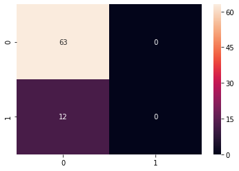

```python
sns.heatmap(cf_matrix, annot=True)
```

```python
recall_score(y_test,y_pred)
```

```
0.0
```

```python
precision_score(y_test,y_pred)
```

```
0.0
```

### Initial Result for Logistic Regression model

[figure not shown]

**6.2 | Training the Random Forest model**

```python
rf=RandomForestClassifier()
```

```python
rf.fit(X_train,y_train)
```

```
RandomForestClassifier()
```

```python
y_pred2=rf.predict(X_test)
```

```python
accuracy_score(y_test,y_pred2)
```

```
0.9333333333333333
```

```python
recall_score(y_test,y_pred2)
```

```
0.9166666666666666
```

```python
precision_score(y_test,y_pred2)
```

```
0.7333333333333333
```

```python
cf_matrix2=confusion_matrix(y_test,y_pred2)
```

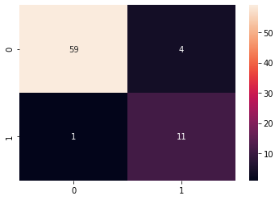

```python
sns.heatmap(cf_matrix2, annot=True)
```

### Initial Result for Random Forest model

[figure not shown]

In Logistic Regression model we have accuracy of the model is 84% on test data and both of recall and precision rate score are 0 which mean adding data did not imporve the scores.

Original: recall score: 0.875 & precision rate: 0.66.

# **7 | Comparison**

**7.1 | Unemployment Rate Plot**

NOTE: Unemployment Rate: people with mental illness vs people without mental illness

Standard Deviation Formula(Population)

$\sigma = \sqrt{\frac{\Sigma(X - \mu)^2}{N}}$

- $X$ - The Value in the data distribution</li>
- $\mu$ - The Population Mean </li>
- $N$ - Total Number of Observations</li>

Standard Deviation Formula(Sample)

$\sigma = \sqrt{\frac{\Sigma(X - \bar{x})^2}{n-1}}$

- $X$ - The Value in the data distribution</li>
- $\bar{x}$ - The Sample Mean </li>
- $n$ - Total Number of Observations</li>

Confidence interval

A confidence interval gives an estimated range of values which is likely to include an unknown population parameter, the estimated range being calculated from a given set of sample data. (Definition taken from Valerie J. Easton and John H. McColl's Statistics Glossary v1.1)

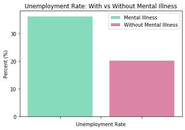

```
 Unemployment Rate
---------------------------------------
 With Mental Illness: 36.47 ± 10.23 %
 Without Mental Illness: 20.42 ± 4.65 %
```

```python
# Plot unemployment rate betweeen those with mental illness and without

df['I identify as having a mental illness'] = y
unemployed_percent = df.loc[df['I identify as having a mental illness'] == 1, 'I am unemployed'].sum(axis=0)
unemployed_percent = unemployed_percent/df.loc[df['I identify as having a mental illness'] == 1, 'I am unemployed'].count()
unemployed_percent = round(unemployed_percent,4)*100

unemployed_percent_without = df.loc[df['I identify as having a mental illness'] < 1, 'I am unemployed'].sum(axis=0)
unemployed_percent_without = unemployed_percent_without/df.loc[df['I identify as having a mental illness'] < 1, 'I am unemployed'].count()
unemployed_percent_without = round(unemployed_percent_without,4)*100

n_1 = df.loc[df['I identify as having a mental illness'] == 1, 'I am unemployed'].count()
n_2 = df.loc[df['I identify as having a mental illness'] < 1, 'I am unemployed'].count()

SD_1 = round(np.sqrt(((unemployed_percent/100) * (1 - unemployed_percent/100))/n_1), 4) * 100
SD_2 = round(np.sqrt(((unemployed_percent_without/100) * (1 - unemployed_percent_without/100))/n_2), 4) * 100

# 1.96 is used because the 95% confidence interval has only 2.5% on each side.
# confidence interval = standard deviation times 1.96
CI_1 = SD_1 * 1.96
CI_2 = SD_2 * 1.96

# Set width of bar
barWidth = .8

# Set height of bar
bars1 = unemployed_percent
bars2 = unemployed_percent_without

# Make the plot
plt.bar(.5,bars1, color='#85DCBA', width=barWidth, edgecolor='white', label='Mental Illness')
plt.bar(1.5,bars2, color='#DC85A7', width=barWidth, edgecolor='white', label='Without Mental Illness')
frame1 = plt.gca()
frame1.axes.xaxis.set_ticklabels([])

# Create legend & Show graphic
plt.title('Unemployment Rate: With vs Without Mental Illness')
plt.xlabel('Unemployment Rate')
plt.ylabel('Percent (%)')
plt.legend()
plt.rcParams['figure.figsize'] = 8, 10
plt.rcParams['font.size'] = 16
plt.show()
print(f'\033[1m Unemployment Rate \033[0m')
print(f'---------------------------------------')
print(f'\033[1m With Mental Illness:\033[0m {round(unemployed_percent,2)} ± {round(CI_1,2)} %')
print(f'\033[1m Without Mental Illness:\033[0m {round(unemployed_percent_without,2)} ± {round(CI_2,2)} %')
```

**7.2 | Tiredness for people from different Region Plot**

```python
df = df_v.append(df_d_new, ignore_index = True)
df1 = df.copy()
df1 = pd.DataFrame(df1, columns=df1.columns)
df1 = df1.rename(columns={'Annual income (including any social welfare programs) in USD': 'Total Annual Income', 'Total length of any gaps in my resume in months.': 'Gaps in Employment in Months'})
```

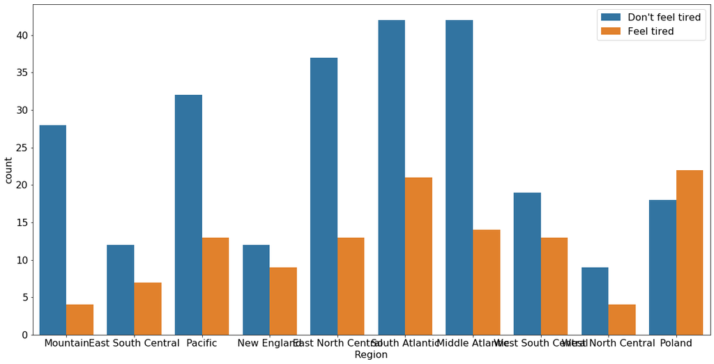

```python
plt.figure(figsize=(20,10))
sns.countplot(x=df1['Region'], hue=df1["Tiredness"])
plt.legend(["Don't feel tired","Feel tired"], loc="upper right")
```

**7.3 | Mental Illness for different Gender Table Poland Included and Excluded**

```python
# Look at the relationship between gender and self identified mental illness Poland included
df1['Gender_Binary'] = 0
df1.loc[df1['Gender'] == "Female", 'Gender_Binary'] = 1
gender_binary = df1['Gender_Binary']
gender = df1['Gender']
illness = df1['I identify as having a mental illness']
res = pd.crosstab(gender, illness.eq(1), rownames={'gender'})
print(res)
```

```
I identify as having a mental illness  False  True
gender
Female                                   149     49
Male                                     140     36
```

```python
# Look at the relationship between gender and self identified mental illness Poland Excluded
df_v['Gender_Binary'] = 0
df_v.loc[df_v['Gender'] == "Female", 'Gender_Binary'] = 1
gender_binary = df_v['Gender_Binary']
gender = df_v['Gender']
illness = df_v['I identify as having a mental illness']
res = pd.crosstab(gender, illness.eq(1), rownames={'gender'})
print(res)
```

```
I identify as having a mental illness  False  True
gender
Female                                   129     47
Male                                     125     33
```

We can see that females are more likely to have mental illeness rather than man.

**7.4 | Education for people from different Region Plot**

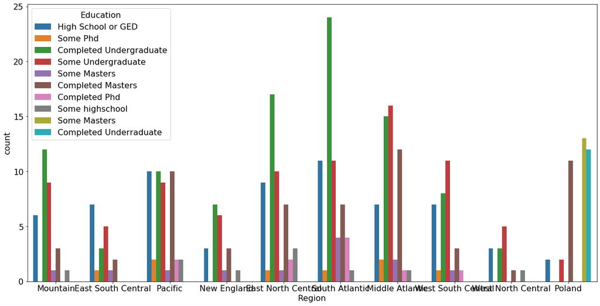

```python
a4_dims = (20,10)
fig, ax = plt.subplots(figsize=a4_dims)
sns.countplot(x=df1['Region'], hue=df1["Education"])
#sns.countplot(ill)
```